# Mushroom Classification

Yujing Song

4/28/2018

# View the data

```r
library(e1071)
library(party)
library(class)
library(rpart)
library(kknn) #for some reason, knn does not work in this situation
mushrooms_raw=read.csv("mushrooms.csv", header = TRUE)
```

# Assumption

We have independent identically distribution as our data generation distribution.

# Observe the data

```r
mushroom_df=as.data.frame(mushrooms_raw)
summary(mushroom_df)
```

```
##  class    cap.shape cap.surface   cap.color    bruises       odor
##  e:4208   b: 452    f:2320      n      :2284   f:4748   n      :3528
##  p:3916   c:   4    g:   4      g      :1840   t:3376   f      :2160
##           f:3152    s:2556      e      :1500            s      : 576
##           k: 828    y:3244      y      :1072            y      : 576
##           s:  32                w      :1040            a      : 400
##           x:3656                b      : 168            l      : 400
##                                 (Other): 220            (Other): 484
##  gill.attachment gill.spacing gill.size   gill.color   stalk.shape
##  a: 210          c:6812       b:5612    b      :1728   e:3516
##  f:7914          w:1312       n:2512    p      :1492   t:4608
##                                         w      :1202
##                                         n      :1048
##                                         g      : 752
##                                         h      : 732
##                                         (Other):1170
##  stalk.root stalk.surface.above.ring stalk.surface.below.ring
##  ?:2480     f: 552                   f: 600
##  b:3776     k:2372                   k:2304
##  c: 556     s:5176                   s:4936
##  e:1120     y:  24                   y: 284
##  r: 192
##
##
##  stalk.color.above.ring stalk.color.below.ring veil.type veil.color
##  w      :4464           w      :4384           p:8124    n:  96
##  p      :1872           p      :1872                     o:  96
##  g      : 576           g      : 576                     w:7924
##  n      : 448           n      : 512                     y:   8
##  b      : 432           b      : 432
##  o      : 192           o      : 192
##  (Other): 140           (Other): 156
##  ring.number ring.type spore.print.color population habitat
##  n:  36      e:2776    w      :2388      a: 384     d:3148
##  o:7488      f:  48    n      :1968      c: 340     g:2148
##  t: 600      l:1296    k      :1872      n: 400     l: 832
##              n:  36    h      :1632      s:1248     m: 292
##              p:3968    r      :  72      v:4040     p:1144
##                        b      :  48      y:1712     u: 368
##                        (Other): 144                 w: 192
```

# Dividing testing data and training data

```r
#randomize the order of the table
random_mushroom = mushroom_df[sample(nrow(mushroom_df)),]

#setting training data and testing data(80% training data and 20% testing data)
training_data=random_mushroom[1:6498,]
testing_data=random_mushroom[6499:8124,]

testing_vars=testing_data[,-1]

sapply(training_data,function(x) sum(is.na(x)))
```

```
##                    class                cap.shape              cap.surface
##                        0                        0                        0
##                cap.color                  bruises                     odor
##                        0                        0                        0
##          gill.attachment             gill.spacing                gill.size
##                        0                        0                        0
##               gill.color              stalk.shape               stalk.root
##                        0                        0                        0
## stalk.surface.above.ring stalk.surface.below.ring   stalk.color.above.ring
##                        0                        0                        0
##   stalk.color.below.ring                veil.type               veil.color
##                        0                        0                        0
##              ring.number                ring.type        spore.print.color
##                        0                        0                        0
##               population                  habitat
##                        0                        0
```

```r
#Noticed that column "veil.type" only has one level, we would like to delete it.
training_data$veil.type = NULL
testing_data$veil.type = NULL
```

# Fitting the Naive Bayes model

```r
#create the model based on naive bayes model
Naive_Bayes_Model=naiveBayes(as.factor(class)~., data=training_data)
Naive_Bayes_Model
```

```
##
## Naive Bayes Classifier for Discrete Predictors
##
## Call:
## naiveBayes.default(x = X, y = Y, laplace = laplace)
##
## A-priori probabilities:
## Y
##         e         p
## 0.5192367 0.4807633
##
## Conditional probabilities:
##    cap.shape
## Y              b            c            f            k            s
##   e 0.0966212211 0.0000000000 0.3778897451 0.0542382928 0.0080023711
##   p 0.0124839949 0.0006402049 0.4010883483 0.1507682458 0.0000000000
##    cap.shape
## Y              x
##   e 0.4632483699
##   p 0.4350192061
##
##    cap.surface
## Y              f            g            s            y
##   e 0.3648488441 0.0000000000 0.2685240071 0.3666271488
##   p 0.1920614597 0.0009603073 0.3581946223 0.4487836108
##
##    cap.color
## Y             b           c           e           g           n
##   e 0.012151749 0.006520451 0.144339063 0.246591583 0.302608180
##   p 0.032010243 0.003201024 0.221190781 0.208386684 0.257682458
##    cap.color
## Y             p           r           u           w           y
##   e 0.013337285 0.004445762 0.004149378 0.170124481 0.095732069
##   p 0.021766965 0.000000000 0.000000000 0.082266325 0.173495519
##
##    bruises
## Y           f         t
##   e 0.3426200 0.6573800
##   p 0.8370679 0.1629321
##
```

[output cut: 97 more lines]

```
##   p 0.00000000 0.45646607 0.00000000
##
##    population
## Y            a          c          n          s          v          y
##   e 0.09187908 0.07083580 0.09365738 0.21102549 0.28275044 0.24985181
##   p 0.00000000 0.01312420 0.00000000 0.09635083 0.72247119 0.16805378
##
##    habitat
## Y             d           g           l           m           p
##   e 0.445465323 0.335210433 0.056609366 0.061647896 0.031713100
##   p 0.325544174 0.192701665 0.149487836 0.009603073 0.253201024
##    habitat
## Y             u           w
##   e 0.022228809 0.047125074
##   p 0.069462228 0.000000000
```

```r
#do the classification based on the naive bayes model
NB_prediction= predict(Naive_Bayes_Model,testing_vars)
#Confusion matrix to check accuracy
table(NB_prediction,testing_data$class)
```

```
##
## NB_prediction   e   p
##             e 830  90
##             p   4 702
```

# Interprete the result

But the problem is the data set for our training and testing data with small size, it may have larger bias with the real-world situation.

# Second try: to do a decision tree

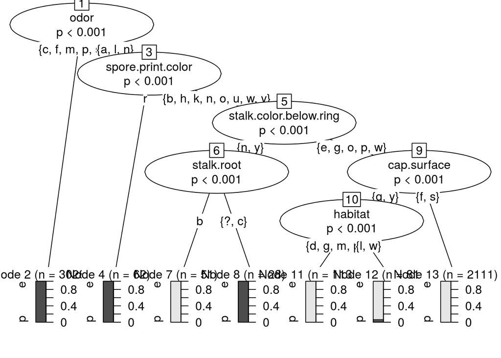

```r
tree = ctree(as.factor(class)~., data = training_data)
plot(tree)
```

```r
#regression_model = glm(formula = class ~ ., family = binomial(link = "logit"), data = training_data)
#summary(regression_model)
```

```r
#pcol <- as.character(as.numeric(training_data$class))
#pairs(training_data[1:4], pch = pcol, col = c("green3", "red"))
#(I am not very understand this plot yet.)
```

# Third try: SVM

```r
sv_model<-svm(class~.,data=training_data,cross=5,type='C-classification',kernel='sigmoid')
summary(sv_model)
```

```
##
## Call:
## svm(formula = class ~ ., data = training_data, cross = 5, type = "C-classification",
##     kernel = "sigmoid")
##
##
## Parameters:
##    SVM-Type:  C-classification
##  SVM-Kernel:  sigmoid
##        cost:  1
##       gamma:  0.01041667
##      coef.0:  0
##
## Number of Support Vectors:  752
##
##  ( 377 375 )
##
##
## Number of Classes:  2
##
## Levels:
##  e p
##
## 5-fold cross-validation on training data:
##
## Total Accuracy: 98.72268
## Single Accuracies:
##  98.61432 98 98.84527 99 99.15385
```

```r
#testing the model
svm_prediction= predict(sv_model,testing_vars)
table(svm_prediction,testing_data$class)
```

```
##
## svm_prediction   e   p
##              e 834  16
##              p   0 776
```

From the table, we noticed that the accuracy of svm model goes to 99% after 5-fold cross-validation.

# Fourth try: neural network

```r
library(nnet);
library(mlbench);
```

```r
#We get all the variables as input, hide layer has 3 nodes, initial random weights interval[-0.1,0.1],weight gradually decay.
nn_model=nnet(class~.,data = training_data,size=3,rang=0.1,decay=5e-4,maxit=200);
nn_predict = predict(nn_model,testing_vars)
compareTable=data.frame(true=testing_data$class,prob=nn_predict)
acc=function(comparetable){
  trueNum=0
  for (i in 1:length(comparetable[,1])){
    if (compareTable[i,1]=="e" && compareTable[i,2]<=0.5){
      trueNum=trueNum+1
    }else if (compareTable[i,1]=="p" && compareTable[i,2]>0.5){
      trueNum=trueNum+1
    }
  }
  return(trueNum/1626)
}
acc(compareTable)
```

```
## [1] 1
```

```r
#change the node to 10
#nn_model10=nnet(class~.,data = training_data,size=10,rang=0.1,decay=5e-4,maxit=10000)
#nn_predict10=predict(nn_model10,testing_vars)
#compareTable10=data.frame(true=testing_data$class,prob=nn_predict10)
#acc(compareTable10)
```

So from above, we get the accuracy of prediction goes to 100%.

```r
library(devtools)
library(scales)
library(reshape)
```

```r
source_url('https://gist.githubusercontent.com/fawda123/7471137/raw/466c1474d0a505ff044412703516c34f1a4684a5/nnet_plot_update.r')
```

```
## SHA-1 hash of file is 74c80bd5ddbc17ab3ae5ece9c0ed9beb612e87ef
```

[figure not shown]

```r
plot.nnet(nn_model)
```

# Other models I have tried

1. Logistic regression. The model shows the variables are non-related with our predicting data, which may because our variables are all factor variables so that linear regression model cannot do a lot of work here.
2. K nearest neighbor. KNN is not help a lot in this situation (k is hard to define) since variables are all factor variables. (KNN will be very helpful, sometimes even better than SVM, if we have multi-modal classification question)